# [MODIS based time series analysis using BFAST](http://changemonitor-wur.github.io/)

Author: Jan Verbesselt

Date: 21 March, 2016

Website: http://changemonitor-wur.github.io/

# Introduction

This document explains how to use R scripting language for downloading MODIS data and analysing it within R. The results of the analysis of MODIS data within R are illustrated. For this time series analysis demonstration it is not required to know R details, we only use R for some practical demonstration of its great potential. In this exercise we will automatically download MODIS data for specific locations, i.e. Flux tower sites, around the world. First, an introduction to MODIS satellite data and the flux tower sites follow. Second, the use of R is introduced. Finally, the exercise in R is explained, step by step.

# MODIS satellite data

The MODIS satellite data that we will download for this time series analysis exercise is available from [the following site](http://daac.ornl.gov/cgi-bin/MODIS/GR_col5_1/mod_viz.html). MODIS data is made available for subsets above a global network of flux towers. FLUXNET, a "network of regional networks", coordinates regional and global analysis of observations from micrometeorological tower sites. The flux tower sites use eddy covariance methods to measure the exchanges of carbon dioxide (CO<sub>2</sub>), water vapor, and energy between terrestrial ecosystems and the atmosphere. The FLUXNET database contains information about tower location and site characteristics as well as data availability. More information above what a flux tower is and the network of flux towers can be found [here](http://www.fluxnet.ornl.gov/).

For this exercise we will focus on the analysis of MODIS satellite data available for these flux towers. More specifically, we will look at the MODIS product called MOD13Q1 which are global 16-day images at a spatial resolution of 250 m. Each image contains several bands; i.e. blue, red, and near-infrared reflectances, centered at 469-nanometers, 645-nanometers, and 858-nanometers, respectively, are used to determine the MODIS vegetation indices.

The MODIS Normalized Difference Vegetation Index (NDVI) complements NOAA's Advanced Very High Resolution Radiometer (AVHRR) NDVI products and provides continuity for time series historical applications. MODIS also includes a new Enhanced Vegetation Index (EVI) that minimises canopy background variations and maintains sensitivity over dense vegetation conditions. The EVI also uses the blue band to remove residual atmosphere contamination caused by smoke and sub-pixel thin cloud clouds. The MODIS NDVI and EVI products are computed from atmospherically corrected bi-directional surface reflectances that have been masked for water, clouds, heavy aerosols, and cloud shadows. Vegetation indices are used for global monitoring of vegetation conditions and are used in products displaying land cover and land cover changes. These data may be used as input for modeling global biogeochemical and hydrologic processes and global and regional climate. These data also may be used for characterizing land surface biophysical properties and processes, including primary production and land cover conversion.

We will work with the MODIS NDVI band within the MOD13Q1 product. More information about this MODIS product can be found [here](https://lpdaac.usgs.gov/dataset_discovery/modis/modis_products_table/mod13q1). Go to the NDVI and the pixel reliability Layer information and have a look:

- above the table on the lower part of the webpage you can click on the `+` sign of the layers
- See the final column of the first table: *Science Data Sets for MODIS Terra Vegetation Indices 16-Day L3 Global 250m SIN Grid V005 (MOD13Q1)* to find the answer of the question below.
- then look at the Table 1: MOD13Q1 Pixel Reliability and Table 2: MOD13Q1 VI Quality) for finding the answer of the second question. Read the text above the table carefully to understand what the table and information means.

> Question 1: By what factor does the 250m MODIS NDVI image layer need to be multiplied in order to obtain values between 0 and 1?

> Question 2: What rank key (number?) would you use to obtain Good Data (see Table 1)?

More info for Question 2:

- **Pixel reliability**: Useful in post processing analysis and recaps the QA status of the product. This parameter is a simple decimal number that ranks the product into five categories [Good-Marginal-Snow/Ice-Cloudy-NoData]. Users can consult this layer instead of working with the `VI_QA layer`. The `VI_QA` layer is still present and can be used for detailed analysis (Table 2).

# Online Analysis of MODIS satellite image data

Please go to the [MODIS Land subsets website](http://daac.ornl.gov/cgi-bin/MODIS/GR_col5_1/mod_viz.html):

Now let's look at the MODIS data time series via this website. Do the following steps:

- *Select Country*: The Netherlands and select the Loobos Site.
- Click on *Time Series Advanced Version* (User Defined QC setting) and select the MOD13Q1 data.

> Question 3: At which pixel number is the flux tower (i.e. the Site pixel) positioned in the MODIS 250m data grid (have a look at the link for corner coordinates and site details)

> Question 4: What happens with the NDVI Filter Applied Graph if you select only data that you can *use with Confidence*?

Extra info:

- Click on the google maps, choose satellite view, link to investigate the land cover type. It is mainly forested by Pinus Sylvestris or also called Scots Pine.
- via the [MODIS Land subsets website](http://daac.ornl.gov/cgi-bin/MODIS/GR_col5_1/mod_viz.html), the data can be downloaded manually. In the tutorial we will automatically download MODIS data using R scripting.

# Getting started with R

We will download the MODIS data for the Loobos Site via R and process the data for one location to detect changes within the time series.

Now follow the following tutorial on getting started with [R and Rstudio](https://geoscripting-wur.github.io/Scripting4GeoIntro/#Basic_R_and_RStudio_setup) (click on this link), in case you have not followed the *geo-scripting* class.

# Install packages and define functions for MODIS data analysis

Now we are ready to get started with the MODIS time series analysis exercise in R! First, choose your working directory (i.e. a folder on your hard drive) to which the MODIS data will be downloaded and where you will save your R script. Set your workdirectory in R using the `setwd()` command. Remark: on your computer the file path looks different on windows! In R you have to change the backslash symbol to a forward slash symbol e.g.:

```r
## "c:\student\MODIS"
setwd(c("c:/student/MODIS/")) ## set your working directory
getwd() ## to check what your working directory is, all good?!
```

Second, make sure your packages installed in R are up-to-date by:

```r
update.packages(ask=FALSE)
```

Third, necessary add-on packages need to be installed within R before loading them in `R` using the `library()` function. Below we define a helper function that does installing and loading of the packages for us.

```r
# pkgTest is a helper function to load packages and install packages only when they are not installed yet.
pkgTest <- function(x)
{
  if (x %in% rownames(installed.packages()) == FALSE) {
    install.packages(x, dependencies= TRUE)
  }
  library(x, character.only = TRUE)
}
neededPackages <- c("strucchange","forecast","zoo", "bfast")
for (package in neededPackages){pkgTest(package)}
```

Now you can check if bfast is installed:

```r
## we install the latest bfast package from the R-forge website
install.packages("bfast", repos="http://R-Forge.R-project.org", dependencies=TRUE)

## for mac users you can do
install.packages("bfast", repos="http://R-Forge.R-project.org",
                 dependencies=TRUE, type = "source")
```

The two functions defined in the section below need to be run **at once** (select all of them in the R script window and do *Crtl-r*). This will define two functions which we will need to process the MODIS data time series. So nothing will happen now in R, but the function are loaded and ready to be used in the script sections below.

> Note: you do not need to understand the details of the two functions below. Make sure you know how to use them. Understanding the details of the two functions below is only for advanced R users (so optional and not required for the AEO course).

```r
## a function to create a regular "ts" (time series) object in R using time information (dt)
timeser <- function(index,dt) {
    z <- zoo(index,dt)
    yr <- as.numeric(format(time(z), "%Y"))
    jul <- as.numeric(format(time(z), "%j"))
    delta <- min(unlist(tapply(jul, yr, diff))) # 16
    zz <- aggregate(z, yr + (jul - 1) / delta / 23)
    (tso <- as.ts(zz))
    return(tso)
}

## a function to remove values (set NA)
## that do not equal a certain criteria
sel <- function(y,crit){
    ts.sel <- y
    ts.sel[!crit] <- NA
    return(ts.sel)
}
```

# Downloading MODIS data using R script

Now we are ready to start downloading the MODIS data. There are two methods: * automatic downloading via the ftp server in the U.S. within R using the code section below * manual downloading of the data.

We will use the automatic downloading method for the exercise (easier;-)).

## Automatic MODIS data downloading

We will use this method in the exercise as long as the server in the U.S. is online and working (you need internet connection, and also keep in mind that the file can be more than 15Mb large).

```r
getwd() ## the file is downloaded to your working directory
```

```r
fluxtower <- c("fn_nlloobos.txt")

## the ftp link to the data, is combine with the fluxtower name below
## see `?paste' for more info and try out the example section
filename <- paste(
"ftp://daac.ornl.gov//data/modis_ascii_subsets//C5_MOD13Q1/data/MOD13Q1."
, fluxtower,sep="")

## now we will download the file only if the .csv file does not exist yet on your computer
## and then read the csv file using the 'read.csv' function

 if(!file.exists(fluxtower)) {
  download.file(filename,fluxtower)
    modis <- read.csv(fluxtower, colClasses = "character")
} else {
    modis <- read.csv(fluxtower, colClasses = "character")
}
## if the above step does not work you can download the data manually
## (go to 'Manual Downloading').
```

By running the lines above the MODIS data subset for the Loobos fluxtower (the Netherlands) is downloaded to the`modis` variable. Please be patient when running the code section above.

Data for a different fluxtower, a fluxtower in New South Wales, Australia, can be downloaded by changing the `fluxtower` variable using the following line:

```r
fluxtower <- c("fn_autumbar.txt")
```

Now try and change the name of the flux tower site to a name of your choice and then rerun the section above to download data for another flux tower. You can select your own fluxtower via:

- The names of the flux towers for which MODIS data is available can be found in the following file available via this link: MODISSubsetSiteInformation , which you can open in Excel or via R (e.g. see the function `read.csv`). The names that you need are in the `Site_ID` column.

## Manual MODIS data Downloading

If the above section does not work, you can download the data manually into your working directory via the following site: [ModisViZ](http://daac.ornl.gov/cgi-bin/MODIS/GR_col5_1/mod_viz.html) and can be loaded in R via the R script below. Things to do to download the data manually:

- download the .txt file from the MODIS Land Subsets website mentioned above, go to the e.g. Loobos site, click download the ASCII file, do *save as*, **txt** file to save to a local folder, and rename the file to e.g. NDVIMOD13Q1.
- Read the data from R with the following R script lines.

You can read in the data file using the following command. Now the MODIS data is loaded!

```r
modis <- read.csv("NDVIMOD13Q1.txt")
```

# Visualising modis time series above the fluxtower

## Plotting a MODIS NDVI time series

We select band 5 i.e. the NDVI band, and band 7 i.e. the band with reliability information

```r
ndvibandname <- modis$Band[5]
rel <- modis$Band[7]
```

We will select data for the pixel above the Loobos Fluxtower. Have a look at [LoobosSiteInfo](http://daac.ornl.gov/cgi-bin/MODIS/GR_col5_1/corners.1.pl?site=fn_nlloobos&res=250m).

It is pixel number 436. Each column after the 6th column in the MODIS file contains data of one pixel so to select the data above the flux tower we have to add 6 to select the correct column within the matrix. The code section below will select the MODIS data for one pixel, scale the NDVI data by dividing it by 10000, and then plot the resulting variable `ts.NDVI` using the `plot()` function:

```r
j <- (436)+6 # we are adding 6 since the first data column is the 7th column
reliability <- as.numeric(modis[modis$Band == rel, j]) # reliability data
NDVI <- as.numeric(modis[modis$Band == ndvibandname, j]) # NDVI data
DATUM <- modis[modis$Band == ndvibandname, 3] # dates
DATUM <- as.Date(DATUM,"A%Y%j") # convert to a datum type
```

Now, let's create a time series! The NDVI value need to be scaled between 0-1 by dividing them by 10000. Attention! The `Zoo` package is needed within the `timeser` function so we load the package using the line below.

```r
library(zoo) ## load the package
ts.rel <- timeser(reliability, DATUM)
ts.NDVI <- timeser(NDVI/10000, DATUM)
```

Now plot the resulting `ts.NDVI` object:

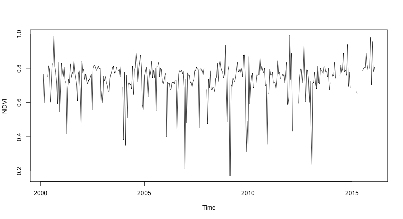

```r
plot(ts.NDVI, ylab = "NDVI")
```

> Question 5: Below a code section is provided that you can use (copy/paste and customize). Select multiple pixels (e.g. 6 pixels) and derive an average, maximum, and median of the selected time series. Now make a plot showing the average, maximum, or median of the 3 NDVI time series. Compare the median NDVI time series with the NDVI time series of the flux tower and copy paste the R plot output in your report. Which approach do you think would be suitable to reduce the noise within a time series? Explain why?

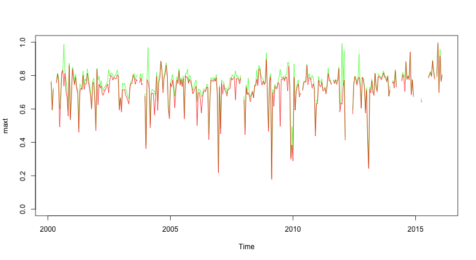

```r
## this is an example for two pixels
## try it out and customize for your own needs
j <- 442:444
t <- modis[modis$Band == ndvibandname, j] # extract NDVI data
tt <- data.matrix(t)/10000 ## convert to a data matrix and divide by 10000
ttt <- ts(apply(tt, 2, timeser, DATUM), start=c(2000,4), freq=23)
## convert to a regular time series object
## plot(ttt) ## plot all the time series
## derive the statistics (max, mean):
maxt <- ts(apply(ttt, 1, max, na.rm=TRUE), start=c(2000,4), freq=23)
meant <- ts(apply(ttt, 1, mean, na.rm=TRUE), start=c(2000,4), freq=23)
## plot
plot(maxt, col="green", ylim=c(0,1))
lines(meant, col="red")
```

## Use the MODIS Reliability information to clean the NDVI time series

Now, we will visualize MODIS reliability information using the `sel` function defined above.

The code section below plot a red point on the plot for all the data points in the time series with a reliability > 1. You can choose `ts.rel = 1`, or `ts.rel > 2`, or ..., and rerun the plot command again and see what happens.

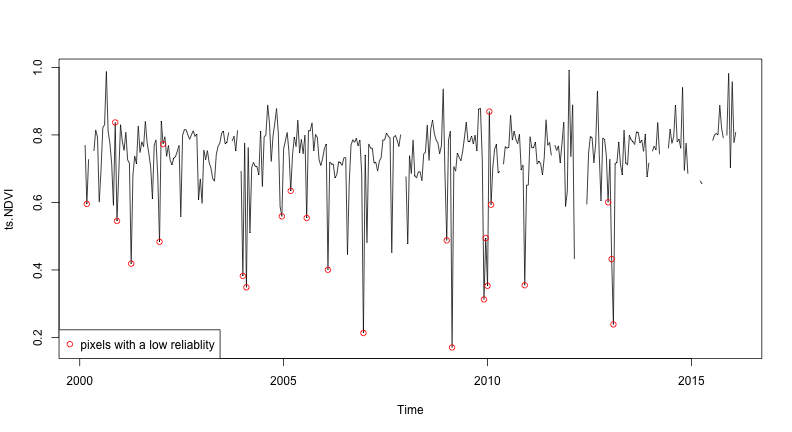

```r
plot(ts.NDVI)
lines(sel(ts.NDVI,ts.rel > 1), col = "red", type = "p")
legend("bottomleft","pixels with a low reliablity",col=2,pch=1)
```

> Question 6: Investigation of MODIS reliability scores. What happens if you select only good quality NDVI data? Can you explain what happens and why this could be? Discuss.

Perform the cleaning and plot the result by running the following lines. The resulting plot will show the MODIS NDVI time series showing red section which indicate the zones that are deleted based on reliability information.

```r
ts.clNDVI <- ts.NDVI
ts.clNDVI[ts.rel > 1] <- NA  # delete data with reliability > 1
```

By applying the two R script lines above, we set all the points with a reliability above 1 to NA (i.e. Not Available which is similar as deleting the value) in the *ts.clNDVI* variable. Now, plot the result of the cleaning and compare with the non-cleaned time series:

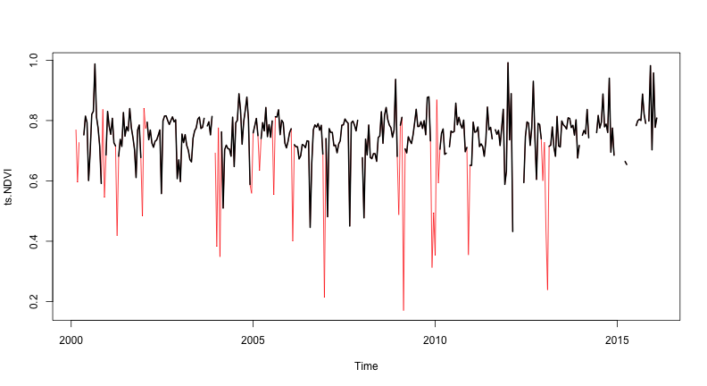

```r
plot(ts.NDVI, col='red')
lines(ts.clNDVI, lwd=2, col='black')
```

There are still clouds effects visible in the NDVI time series after using the MODIS reliability information. The reliability information available with each MODIS image indicates how reliable the data is and is based on the cloud masking results, atmospheric data (aerosol thickness), satellite viewing angle, etc. More information about the reliability is available via the [MODIS Product Table website](https://lpdaac.usgs.gov/products/modis_products_table/mod13q1).

# Applying BFAST on cleaned NDVI time series

In this section we will use BFAST on the cleaned NDVI time series to detect changes within the time series.

First, we will interpolate the gaps in the cleaned NDVI time series using a simple linear interpolation approach. The function that we use for this is the `na.aprox()` function which looks for NA's (Not Available's), which means dates for which no data is available (e.g., that we removed in the previous steps) and interpolates the data. The `plot()` command of the results (`ts.clNDVIfilled`) visualizes the result of the interpolation:

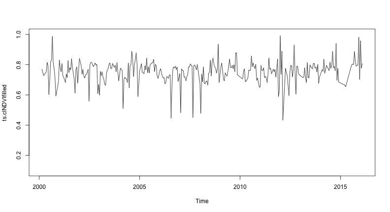

```r
ts.clNDVIfilled <- na.approx(ts.clNDVI)
plot(ts.clNDVIfilled, ylim=c(0.1, 1))
```

Second, we apply the BFAST function onto the time series. We determine this minimum distance between potentially detected breaks. Here, we set the distance to 25 time steps (i.e. 25 16-day images).

Then we apply the BFAST function (`bfast()`) on the time series:

```r
library(bfast)
```

```r
## Warning: no function found corresponding to methods exports from 'raster'
## for: 'overlay'
```

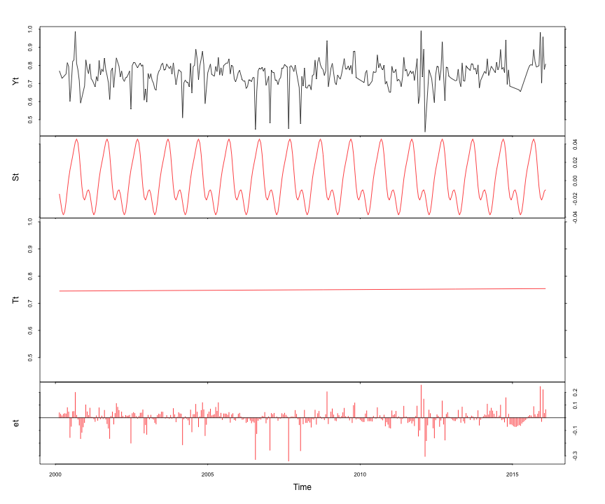

```r
rdist <- 25/length(ts.clNDVIfilled)
## ratio of distance between breaks (time steps) and length of the time series
fit <- bfast(ts.clNDVIfilled, h=rdist,
             season="harmonic", max.iter=1)
plot(fit, main="")
```

> Question 7: copy and paste the resulting R BFAST graph in the report and describe the detected components and change types, detected within the time series. Are there any detected breaks? How strict would you do the cleaning?

> Question 8: Download data from another location on earth and run all the steps mentioned above again in order to apply the BFAST function again onto a new cleaned NDVI time series. Copy the BFAST plot to your report, mention the flux tower that you downloaded the data from and describe the difference with the graph obtained from Question 7.

# Applying BFASTmonitor on the cleaned NDVI time series

To better understand how bfastmonitor works have a look at the help section of the bfastmonitor function and try out the examples provided below.

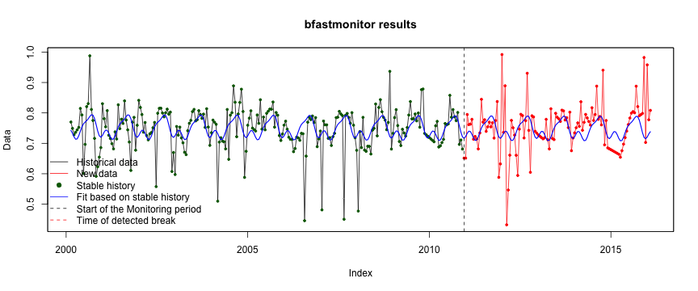

```r
library(bfast)
mon <- bfastmonitor(ts.clNDVIfilled,
                    start = c(2010, 23),
                formula = response ~ harmon + trend,
                    history = c("ROC"))
plot(mon, main="bfastmonitor results")
```

> Question 9: How long (in years) is your selected stable history period? Illustrate this with your own time series from a flux tower of your own choice.

> Question 10: Start the monitoring period the end of 2015. Is 2016 an abnormal year? Illustrate this with your own time series from a flux tower of your own choice.

> Question 11: See the help section of bfastmonitor. Can you explain what the effect is of using a different `formula` in `bfastmonitor()`. For example, what happens if you use `response ~ trend`. Illustrate this with your own time series from a flux tower of your own choice.

```r
?bfastmonitor
```

# More information

More information can be found on the following [website](http://bfast.r-forge.r-project.org/) and in the BFAST papers mentioned on the website.

## Finding information and examples about BFAST

To better understand how BFAST works have a look at the help section of the BFAST function and try out the examples provided.

```r
help(bfast)
## for more info
## try out the examples in the bfast help section!
plot(harvest, ylab="NDVI") # MODIS 16-day cleaned and interpolated NDVI time series
(rdist <- 10/length(harvest))
# ratio of distance between breaks (time steps) and length of the time series
fit <- bfast(harvest, h=rdist, season="harmonic", max.iter=1, breaks=2)
plot(fit)
## plot anova and slope of the trend identified trend segments
plot(fit, main="")
```

## Extra information about the seasonal modelling done within BFAST

A harmonic seasonal model is used within BFAST to account for seasonal variation within BFAST:

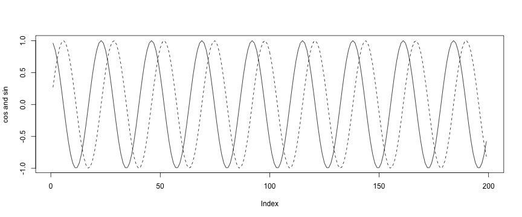

```r
library(bfast)

## a demo ndvi time series:
ndvi <- ts(rowSums(simts$time.series))
tsp(ndvi) <- tsp(simts$time.series)

## input variable for the sinus and cosinus functions
f <- 23
w <- 1/f
tl <- 1:length(ndvi)

## 3th order harmonic model
co <- cos(2 * pi * tl * w)
si <- sin(2 * pi * tl * w)
co2 <- cos(2 * pi * tl * w * 2)
si2 <- sin(2 * pi * tl * w * 2)
co3 <- cos(2 * pi * tl * w * 3)
si3 <- sin(2 * pi * tl * w * 3)

# fit the seasonal model using linear regression
fitm <-  lm(ndvi ~ co + si + co2 + si2 + co3 + si3)
predm <- fitted(fitm) ## predict based on the modelfit

plot(co, type = "l", ylab = "cos and sin")
lines(si, type = "l", lty = 2)
```

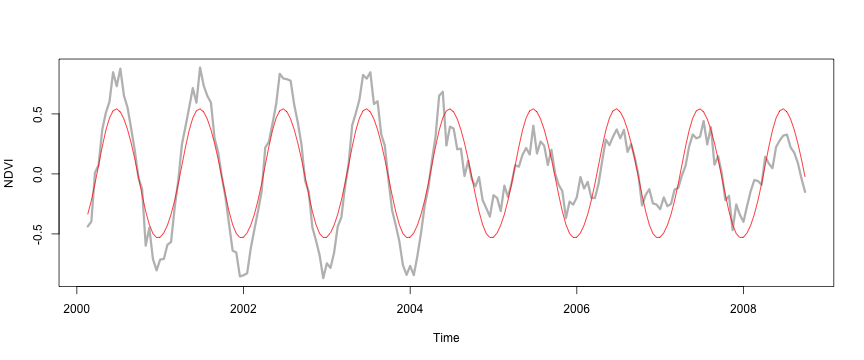

```r
#create time series bfast on the 3th order harmonic function
predm <- ts(as.numeric(predm), start=c(2000,4), frequency=23)
plot(ndvi, lwd = 3, col = "grey", ylab = "NDVI")
lines(predm, type = "l", col = "red") # fitted
```

Styled with knitrBootstrap